# Predicting NFL Quarterback Ratings[^1]

A Least Squares Method and Linear Regression Implementation in R

by Arda Ugur, SeyedAli TaheriTari a_ugur1@u.pacific.edu, s_taheritari@u.pacific.edu University of the Pacific, School of Engineering and Computer Science, Ms. Sci. Data Science

September 2017

[figure not shown]

# 1 Introduction

[Quarterback rating](https://en.wikipedia.org/wiki/Passer_rating) (also known as **passer rating**, or **QB rating**) is a measure of the performance of passers, primarily quarterbacks, in American football. Quarterback rating is calculated using player’s passing attempts, completions, yards, touchdowns, and interceptions. Since 1973, passer rating has been the official formula used by the NFL to determine its passing leader. Passer rating in the NFL is on a scale from 0 to 158.3.

The main objective of this study is to provide an example of the method of **least squares** in [R](https://en.wikipedia.org/wiki/Passer_rating) programming language, using the 2008 NFL quarterback ratings data set, provided below.

2008 NFL Quarterback Ratings

| First | Last | Team | Att | Comp | Pct Comp | Yds | Yds per Att | TD | Pct TD | Long | Int | Pct Int | Rating Pts |
| --- | --- | --- | --- | --- | --- | --- | --- | --- | --- | --- | --- | --- | --- |
| Philip | Rivers | SD | 478 | 312 | 65.3 | 4009 | 8.39 | 34 | 7.1 | 67 | 11 | 2.3 | 105.5 |
| Chad | Pennington | MIA | 476 | 321 | 67.4 | 3653 | 7.67 | 19 | 4.0 | 80 | 7 | 1.5 | 97.4 |
| Kurt | Warner | ARI | 598 | 401 | 67.1 | 4583 | 7.66 | 30 | 5.0 | 79 | 14 | 2.3 | 96.9 |
| Drew | Brees | NO | 635 | 413 | 65.0 | 5069 | 7.98 | 34 | 5.4 | 84 | 17 | 2.7 | 96.2 |
| Peyton | Manning | IND | 555 | 371 | 66.8 | 4002 | 7.21 | 27 | 4.9 | 75 | 12 | 2.2 | 95.0 |
| Aaron | Rodgers | GB | 536 | 341 | 63.6 | 4038 | 7.53 | 28 | 5.2 | 71 | 13 | 2.4 | 93.8 |
| Matt | Schaub | HOU | 380 | 251 | 66.1 | 3043 | 8.01 | 15 | 3.9 | 65 | 10 | 2.6 | 92.7 |
| Tony | Romo | DAL | 450 | 276 | 61.3 | 3448 | 7.66 | 26 | 5.8 | 75 | 14 | 3.1 | 91.4 |
| Jeff | Garcia | TB | 376 | 244 | 64.9 | 2712 | 7.21 | 12 | 3.2 | 71 | 6 | 1.6 | 90.2 |
| Matt | Cassel | NE | 516 | 327 | 63.4 | 3693 | 7.16 | 21 | 4.1 | 76 | 11 | 2.1 | 89.4 |
| Matt | Ryan | ATL | 434 | 265 | 61.1 | 3440 | 7.93 | 16 | 3.7 | 70 | 11 | 2.5 | 87.7 |
| Shaun | Hill | SF | 288 | 181 | 62.8 | 2046 | 7.10 | 13 | 4.5 | 48 | 8 | 2.8 | 87.5 |
| Seneca | Wallace | SEA | 242 | 141 | 58.3 | 1532 | 6.33 | 11 | 4.5 | 90 | 3 | 1.2 | 87.0 |
| Eli | Manning | NYG | 479 | 289 | 60.3 | 3238 | 6.76 | 21 | 4.4 | 48 | 10 | 2.1 | 86.4 |
| Donovan | McNabb | PHI | 571 | 345 | 60.4 | 3916 | 6.86 | 23 | 4.0 | 90 | 11 | 1.9 | 86.4 |
| Jay | Cutler | DEN | 616 | 384 | 62.3 | 4526 | 7.35 | 25 | 4.1 | 93 | 18 | 2.9 | 86.0 |
| Trent | Edwards | BUF | 374 | 245 | 65.5 | 2699 | 7.22 | 11 | 2.9 | 65 | 10 | 2.7 | 85.4 |
| Jake | Delhomme | CAR | 414 | 246 | 59.4 | 3288 | 7.94 | 15 | 3.6 | 65 | 12 | 2.9 | 84.7 |
| Jason | Campbell | WAS | 506 | 315 | 62.3 | 3245 | 6.41 | 13 | 2.6 | 67 | 6 | 1.2 | 84.3 |
| David | Garrard | JAC | 535 | 335 | 62.6 | 3620 | 6.77 | 15 | 2.8 | 41 | 13 | 2.4 | 81.7 |
| Brett | Favre | NYJ | 522 | 343 | 65.7 | 3472 | 6.65 | 22 | 4.2 | 56 | 22 | 4.2 | 81.0 |
| Joe | Flacco | BAL | 428 | 257 | 60.0 | 2971 | 6.94 | 14 | 3.3 | 70 | 12 | 2.8 | 80.3 |
| Kerry | Collins | TEN | 415 | 242 | 58.3 | 2676 | 6.45 | 12 | 2.9 | 56 | 7 | 1.7 | 80.2 |
| Ben | Roethlisberger | PIT | 469 | 281 | 59.9 | 3301 | 7.04 | 17 | 3.6 | 65 | 15 | 3.2 | 80.1 |
| Kyle | Orton | CHI | 465 | 272 | 58.5 | 2972 | 6.39 | 18 | 3.9 | 65 | 12 | 2.6 | 79.6 |
| JaMarcus | Russell | OAK | 368 | 198 | 53.8 | 2423 | 6.58 | 13 | 3.5 | 84 | 8 | 2.2 | 77.1 |
| Tyler | Thigpen | KC | 420 | 230 | 54.8 | 2608 | 6.21 | 18 | 4.3 | 75 | 12 | 2.9 | 76.0 |
| Gus | Frerotte | MIN | 301 | 178 | 59.1 | 2157 | 7.17 | 12 | 4.0 | 99 | 15 | 5.0 | 73.7 |
| Dan | Orlovsky | DET | 255 | 143 | 56.1 | 1616 | 6.34 | 8 | 3.1 | 96 | 8 | 3.1 | 72.6 |
| Marc | Bulger | STL | 440 | 251 | 57.0 | 2720 | 6.18 | 11 | 2.5 | 80 | 13 | 3.0 | 71.4 |
| Ryan | Fitzpatrick | CIN | 372 | 221 | 59.4 | 1905 | 5.12 | 8 | 2.2 | 79 | 9 | 2.4 | 70.0 |
| Derek | Anderson | CLE | 283 | 142 | 50.2 | 1615 | 5.71 | 9 | 3.2 | 70 | 8 | 2.8 | 66.5 |

# 2 Objectives

- **Objective 1** : Create a least squares model to relate the dependent variable **quarterback rating** to the **percentage of completions**.
- **Objective 2** : Create a least squares model to relate the dependent variable **quarterback rating** to the **percentage of completions** and **interceptions**.
- **Objective 3** : Determine the **least squares error** (or the *square root of sum of square errors*) for models in **Objective 1** and **Objective 2**. Does using an additional variable (i.e., percentage of interceptions) improve the accuracy of the linear regression model for this data set?
- **Objective 4** : Using your models from **Objective 1** and **Objective 2** predict the **quarterback rating** for 60% completion and 3% interception.
- **Objective 5** : Go Seahawks!

# 3 Theory

Regression analysis is a conceptually simple method for investigating functional relationships between two or amoung more than two variables. For example, a civil engineer may wish to relate a specific mixture of concrete specimen’s compressive strength to its other physical or mechanical attributes (e.g., compressive strenght versus density, air content, water/cement ratio, etc.) Or an economist may wish to investigate the relationship between the economic structure and environmental pollution level of a country or a region.
The investigated relationship is usually expressed in the form of an equation or a model connecting the **response** (or **dependent**) **variable** and one or more **explanatory** or **predictor variables**.We denote the response variable $Y$ and the set pf predictor variables by $X_1$, $X_2$, …, $X_p$, where $p$ denotes the number of predictor variables. The **true** relationship between $Y$ and $X_1$, $X_2$, …, $X_p$ can be approximated by the following regression model:
$$Y=f(X_1, X_2, ..., X_p) + \epsilon$$
where $\epsilon$ is assumed to be a random error representing the discrepancy in the approximation. It accounts for the failure of the model to fit the data exactly. The function $f(X_1, X_2, ..., X_p)$ describes the relationship between $Y$ and $X_1$, $X_2$, …, $X_p$. An example to such relationship is the **linear regression model** which can be expressed as:
$$Y= \beta_0 + \beta_1X_1 + \beta_2X_2 + ... + \beta_pX_p + \epsilon$$
where $\beta_0, \beta_1, \beta_2, ...,\beta_p$, called the **regressuion parameters** or **regression coefficients**, are the unknown constants to be estimated from the data.
We can also represent **multiple regression analysis** (and **simple regression analysis**) in matrix notation. To do so, first, let us define the following matrices:

$$\begin{equation}
Y = \begin{bmatrix}
y_1 \\
y_2\\
\vdots\\
y_n
\end{bmatrix}
\space\space\space\space\
X = \begin{bmatrix}
1 & x_{11} & x_{12} & \dots & x_{1p}\\
1 & x_{21} & x_{22} & \dots & x_{2p}\\
\vdots & \vdots & \vdots & & \vdots\\
1 & x_{n1} & x_{n2} & \dots & x_{np}\\
\end{bmatrix}
\space\space\space\space\
\beta = \begin{bmatrix}
\beta_1 \\
\beta_2\\
\vdots\\
\beta_p
\end{bmatrix}
\space\space\space\space\
\epsilon = \begin{bmatrix}
\epsilon_1 \\
\epsilon_2\\
\vdots\\
\epsilon_p
\end{bmatrix}
\end{equation}$$

The linear model given earlier, then can be expressed in terms of the matrices presented above as
$$Y = X\beta + \epsilon$$
The least squares estimator $\widehat{\beta}$ of $\beta$ is obtained by minimizing the SSE (Sum of Squared Errors or the sum of squared deviations of the observations from their expected values) as below:
$$SSE=\epsilon_1^2+\epsilon_2^2+...+\epsilon_p^2$$

Consequently,in the matrix notation, the least squares estimators are obtained by minimizing $S(\beta)$, where
$$S(\beta) = \epsilon^T\epsilon = (Y - X\beta)^T(Y - X\beta)$$
Since we can only estimate $\beta$, minimization of $S(\beta)$ takes us to the system of equations
$$(X^TX)\widehat{\beta} = X^TY$$
And finally, provided that $X^TX$ is invertible, the **least squares estimate** $\widehat{\beta}$ can be written as:
$$\widehat{\beta}=(X^TX)^{-1}X^TY$$
Our R implementation for this particular assignment will be based on the mathematical relationships given above. For more detailed information mathematical foundations of linear regression analysis, please refer to the references at the end of this paper.

# 4 Implementation

In the following subsections we are going to implement the objectives given in previous sections.

## 4.1 Objective 1

Let us create a least squares model to relate the response variable **quarterback rating** to the **percentage of completions**

```
## [1] "Matrix for Percentage of Completions:"
```

```
##       [,1] [,2]
##  [1,]    1 65.3
##  [2,]    1 67.4
##  [3,]    1 67.1
##  [4,]    1 65.0
##  [5,]    1 66.8
##  [6,]    1 63.6
##  [7,]    1 66.1
##  [8,]    1 61.3
##  [9,]    1 64.9
## [10,]    1 63.4
## [11,]    1 61.1
## [12,]    1 62.8
## [13,]    1 58.3
## [14,]    1 60.3
```

[output cut: 18 more lines]

```
## [1] "Vector for Quarterback Rating Points"
```

```
##        [,1]
##  [1,] 105.5
##  [2,]  97.4
##  [3,]  96.9
##  [4,]  96.2
##  [5,]  95.0
##  [6,]  93.8
##  [7,]  92.7
##  [8,]  91.4
##  [9,]  90.2
## [10,]  89.4
## [11,]  87.7
## [12,]  87.5
## [13,]  87.0
## [14,]  86.4
```

[output cut: 18 more lines]

Using `ginv` function, we are going to compute the vector for $\beta$ that consists regression coefficients of $\beta_0$ and $\beta_1$.

```
## [1] "Regression Coefficients for Quarterback Rating Points based on Percentage of Completions:"
```

```
##            [,1]
## [1,] -22.033064
## [2,]   1.745626
```

Using computed values in previous steps, let us compute the predicted values of Quarterback Rating Points $(\widehat{Y})$:

```
## [1] "Predicted Quarterback Rating Points:"
```

```
##           [,1]
##  [1,] 91.95633
##  [2,] 95.62214
##  [3,] 95.09845
##  [4,] 91.43264
##  [5,] 94.57477
##  [6,] 88.98876
##  [7,] 93.35283
##  [8,] 84.97382
##  [9,] 91.25808
## [10,] 88.63964
## [11,] 84.62470
## [12,] 87.59226
## [13,] 79.73694
## [14,] 83.22820
```

[output cut: 18 more lines]

Since we have obtained the predicted values, we can compute the residuals and the least squares error as follows:

```
## [1] "Deviation between predicted and observed Quarterback Rating Points:"
```

```
##               [,1]
##  [1,]  13.54367279
##  [2,]   1.77785775
##  [3,]   1.80154561
##  [4,]   4.76736065
##  [5,]   0.42523347
##  [6,]   4.81123734
##  [7,]  -0.65282818
##  [8,]   6.42617762
##  [9,]  -1.05807673
## [10,]   0.76036258
## [11,]   3.07530287
## [12,]  -0.09226169
## [13,]   7.26305625
## [14,]   3.17180383
```

[output cut: 18 more lines]

As the sqare root of sum of squared errors or the residuals vector constitutes the least squares error, we will use `norm` function to compute the length of residuals vector

```
## [1] "The least squares error:"
```

```
## [1] 29.58189
```

We can also plot the observed Quarterback ratings against the predicted values along with a best fit line using `plot` and `line` functions

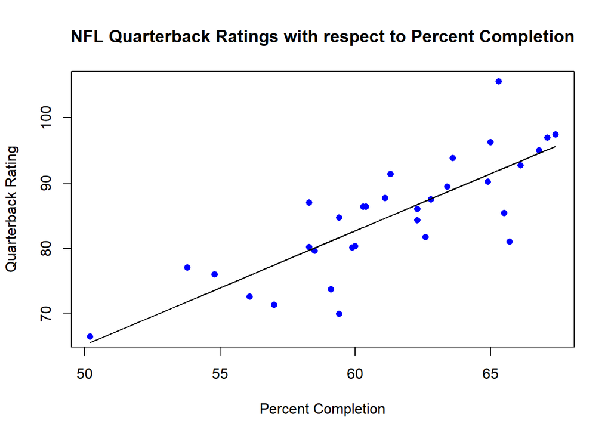

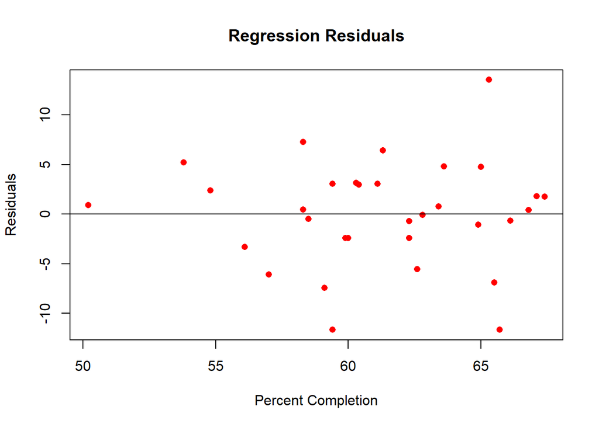

## Objective 2

Let us create multiple linear regression model to relate the response variable **quarterback rating** to the **percentage of completions** and **Interceptions**.

```
## [1] "Matrix for Percentage of Completions and Interceptions:"
```

```
##       [,1] [,2] [,3]
##  [1,]    1 65.3  2.3
##  [2,]    1 67.4  1.5
##  [3,]    1 67.1  2.3
##  [4,]    1 65.0  2.7
##  [5,]    1 66.8  2.2
##  [6,]    1 63.6  2.4
##  [7,]    1 66.1  2.6
##  [8,]    1 61.3  3.1
##  [9,]    1 64.9  1.6
## [10,]    1 63.4  2.1
## [11,]    1 61.1  2.5
## [12,]    1 62.8  2.8
## [13,]    1 58.3  1.2
## [14,]    1 60.3  2.1
```

[output cut: 18 more lines]

```
## [1] "Vector for Quarterback Rating Points"
```

```
##        [,1]
##  [1,] 105.5
##  [2,]  97.4
##  [3,]  96.9
##  [4,]  96.2
##  [5,]  95.0
##  [6,]  93.8
##  [7,]  92.7
##  [8,]  91.4
##  [9,]  90.2
## [10,]  89.4
## [11,]  87.7
## [12,]  87.5
## [13,]  87.0
## [14,]  86.4
```

[output cut: 18 more lines]

```
## [1] "Regression Coefficients for Quarterback Rating Points based on Percentage of Completions and ~ Interceptions:"
```

```
##           [,1]
## [1,] -9.109043
## [2,]  1.662173
## [3,] -3.076368
```

After regression coefficients are obtained, let us compute the predicted values of Quarterback Rating Points $(\widehat{Y})$, in relation to Percentage of Completions and Interceptions:

```
## [1] "Predicted Quarterback Rating Points:"
```

```
##           [,1]
##  [1,] 92.35520
##  [2,] 98.30686
##  [3,] 95.34711
##  [4,] 90.62600
##  [5,] 95.15610
##  [6,] 89.22187
##  [7,] 92.76203
##  [8,] 83.24542
##  [9,] 93.84379
## [10,] 89.81235
## [11,] 84.75880
## [12,] 86.66159
## [13,] 84.10400
## [14,] 84.65961
```

[output cut: 18 more lines]

Since we have obtained the predicted values, we can compute the residuals and the least squares error as follows:

```
## [1] "Deviation between predicted and observed Quarterback Rating Points:"
```

```
##               [,1]
##  [1,]  13.14479769
##  [2,]  -0.90686015
##  [3,]   1.55288640
##  [4,]   5.57399691
##  [5,]  -0.15609855
##  [6,]   4.57812852
##  [7,]  -0.06203016
##  [8,]   8.15458411
##  [9,]  -3.64379097
## [10,]  -0.41234739
## [11,]   2.94119770
## [12,]   0.83841420
## [13,]   2.89600310
## [14,]   1.74038872
```

[output cut: 18 more lines]

As the sqareroot of sum of squared errors or the residuals vector constitutes the least squares error, we will use `norm` function to compute the length of residuals vector

```
## [1] "The least squares error:"
```

```
## [1] 26.58117
```

Based on qbove calculations, you could see following plots about observations points and our regression plane. You can see that our linear assumtion was logical based on information.

[figure not shown]

## 4.2 Objective 3

As we determined the least square errors (square root of sum of squared errors) for each regression model in previous subsections (under Objective 1 and Objective 2), we now can discuss whether using an additional variable(s) improve the accuracy of the regression model for the data set in question?

Let us first revisit the least squares errors for each regression model developed earlier.

```
## [1] "The least squares error for simple linear regression is 29.5818858464847"
```

```
## [1] "The least squares error for multiple linear regression model is 26.5811744686636"
```

As it is the objective of linear regression to minimize the square root of residuals, ignoring other regression diagnostics for the time being, proceeding from the assumption of the smaller the least squares error, better the fit, we can be observed by comparing the least squares errors of linear regression models, the second model which is built on two predictor variables, tends to have less deviation from the actual observed values. Once again, in order to assertain the fitness of a model, we should utilize more sophisticated mathematical tools such as hypothesis testing and confidence intervals.

## 4.3 Objective 4

Using the linear regression models developed in objectives (1) and (2) in parts repsectively, let us try to predict the quarterback rating points for percentage of completions of 60% and percentage of interceptions of 3%.

However, let us start with writing our predictive models below, before plugging in the numbers:

```
## [1] "Beta values for simple linear model of objective 1"
```

```
##            [,1]
## [1,] -22.033064
## [2,]   1.745626
```

```
## [1] "Beta values for multiple linear model of objective 2"
```

```
##           [,1]
## [1,] -9.109043
## [2,]  1.662173
## [3,] -3.076368
```

$$\widehat{Y_a}=-22.033 + 1.746X_1$$
and

$$\widehat{Y_b}=-9.109 + 1.662X_1 -3.076X_2$$
For the simple linear model, using only the percent of completions (60%), we predict that the quarterback rating point will be:

```
## For 60% completion rate, the quarterback rating will be 82.70451
```

For the multiple linear model, using the percent of completions (60%) and percent of intercept (3%), we predict that the quarterback rating point will be:

```
## For 60% completion rate and 3% interception rate, the quarterback rating will be 81.39223
```

## 4.4 Objective 5

[figure not shown]

# 5 Further Study

Let us try to use R lm() package and compare our results.

```r
library(MASS)
library(ISLR)
```

**Simple Linear Regression Using lm() Package**

```
##
## Call:
## lm(formula = response ~ predictor, data = qbrating_matrix)
##
## Residuals:
##      Min       1Q   Median       3Q      Max
## -11.6571  -2.4221   0.4441   3.0510  13.5437
##
## Coefficients:
##             Estimate Std. Error t value Pr(>|t|)
## (Intercept) -22.0331    14.3940  -1.531    0.136
## predictor     1.7456     0.2346   7.440 2.73e-08 ***
## ---
## Signif. codes:  0 '***' 0.001 '**' 0.01 '*' 0.05 '.' 0.1 ' ' 1
##
## Residual standard error: 5.401 on 30 degrees of freedom
## Multiple R-squared:  0.6485, Adjusted R-squared:  0.6368
## F-statistic: 55.35 on 1 and 30 DF,  p-value: 2.727e-08
```

```
## (Intercept)   predictor
##  -22.033064    1.745626
```

```
##        1        2        3        4        5        6        7        8
## 91.95633 95.62214 95.09845 91.43264 94.57477 88.98876 93.35283 84.97382
##        9       10       11       12       13       14       15       16
## 91.25808 88.63964 84.62470 87.59226 79.73694 83.22820 83.40276 86.71945
##       17       18       19       20       21       22       23       24
## 92.30545 81.65713 86.71945 87.24314 92.65458 82.70451 79.73694 82.52995
##       25       26       27       28       29       30       31       32
## 80.08607 71.88163 73.62725 81.13344 75.89657 77.46763 81.65713 65.59737
```

```
##            1            2            3            4            5
##  13.54367279   1.77785775   1.80154561   4.76736065   0.42523347
##            6            7            8            9           10
##   4.81123734  -0.65282818   6.42617762  -1.05807673   0.76036258
##           11           12           13           14           15
##   3.07530287  -0.09226169   7.26305625   3.17180383   2.99724121
##           16           17           18           19           20
##  -0.71944858  -6.90545246   3.04286742  -2.41944858  -5.54313645
##           21           22           23           24           25
## -11.65457770  -2.40450830   0.46305625  -2.42994568  -0.48606899
##           26           27           28           29           30
##   5.21837420   2.37274799  -7.43344471  -3.29656609  -6.06762967
##           31           32
## -11.65713258   0.90262855
```

[output not shown]

[output cut: 19 more lines]

```
## $wt.res
##            1            2            3            4            5
##  13.54367279   1.77785775   1.80154561   4.76736065   0.42523347
##            6            7            8            9           10
##   4.81123734  -0.65282818   6.42617762  -1.05807673   0.76036258
##           11           12           13           14           15
##   3.07530287  -0.09226169   7.26305625   3.17180383   2.99724121
##           16           17           18           19           20
##  -0.71944858  -6.90545246   3.04286742  -2.41944858  -5.54313645
##           21           22           23           24           25
## -11.65457770  -2.40450830   0.46305625  -2.42994568  -0.48606899
##           26           27           28           29           30
##   5.21837420   2.37274799  -7.43344471  -3.29656609  -6.06762967
##           31           32
## -11.65713258   0.90262855
```

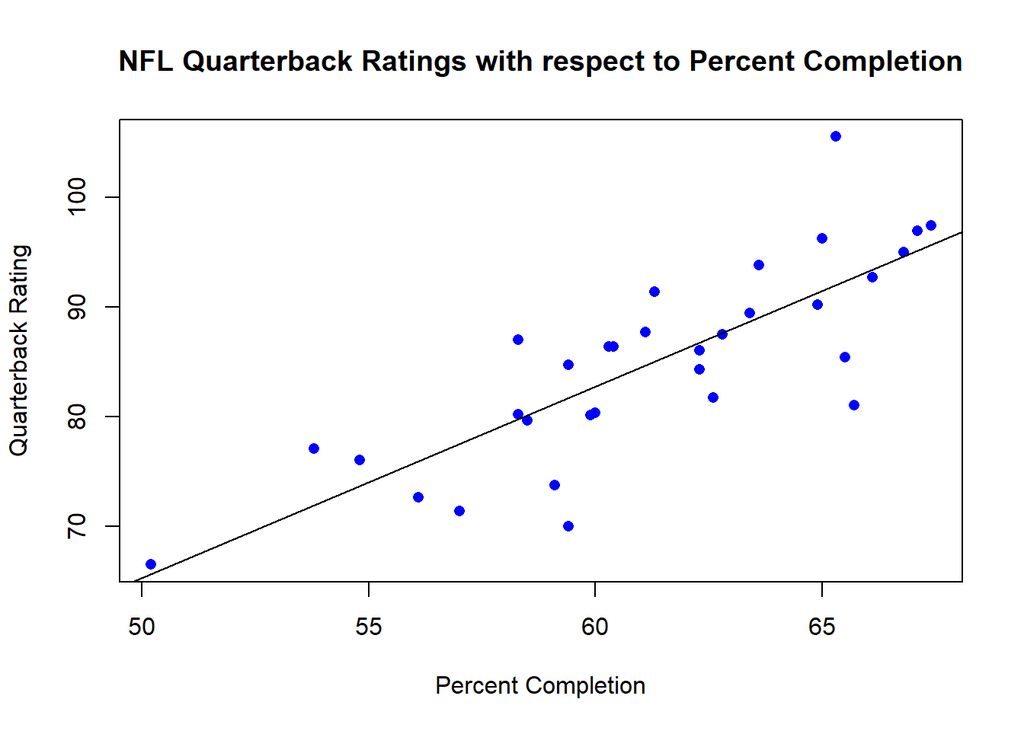

[figure not shown]

```
##
## Call:
## lm(formula = response ~ predictor + predictor2, data = qbrating_matrix)
##
## Residuals:
##      Min       1Q   Median       3Q      Max
## -12.2407  -2.0930  -0.0528   2.9073  13.1448
##
## Coefficients:
##             Estimate Std. Error t value Pr(>|t|)
## (Intercept)  -9.1090    14.0429  -0.649   0.5217
## predictor     1.6622     0.2168   7.668 1.87e-08 ***
## predictor2   -3.0764     1.1697  -2.630   0.0135 *
## ---
## Signif. codes:  0 '***' 0.001 '**' 0.01 '*' 0.05 '.' 0.1 ' ' 1
##
## Residual standard error: 4.936 on 29 degrees of freedom
## Multiple R-squared:  0.7162, Adjusted R-squared:  0.6966
## F-statistic: 36.59 on 2 and 29 DF,  p-value: 1.172e-08
```

# 6 References

1. Zarei, A. (2017), *Linear Algebra for Data Science - Lecture Notes*, University of the Pacific, School of Engineering and Computer Science, Stockton, CA.
2. Chatterjee, S., and Hadi, A. S. (2012), *Regression Analysis by Example*, 5th ed., New Jersey: John Wiley & Sons.
3. James, G., Witten, D., Hastie, T., Tibshirani, R. (2013), *An Introduction to Statistical Learning with Applications in R*, 6th printing (2015), New York, Springger Science+Business Media.
4. Davies, T. M. (2016), *The Book of R: A First Course in Programming and Statistics*, 1st ed., San Francisco: No Starch Press.

# 7 Acknowledgements

The authors wish to thank Dr. A. Zarei for providing guidence and help during the process of completion of this research project.

[^1]: ANLT-201 - Linear Algebra for Data Science / Assignment 01